# Starting to Use R

Website Version

Author

Affiliation

Jon Yearsley

School of Biology and Environmental Science, UCD

Published

May, 2026

**TipHow to Read this Tutorial**

This tutorial is a mixture of R code chunks and explanations of the code. The R code chunks will appear in boxes.

Below is an example of a chunk of R code:

```r
# This is a chunk of R code. All text after a # symbol is a comment
# Set working directory using setwd() function
setwd('Enter the path to my working directory')

# Clear all variables in R's memory
rm(list=ls())    # Standard code to clear R's memory
```

Sometimes the output from running this R code will be displayed after the chunk of code.

Here is a chunk of code followed by the R output

```r
2 + 4            # Use R to add two numbers
```

```
[1] 6
```

# Objectives

The objectives of this tutorial are:

1. Provide an overview of R’s basic functions
2. Describe the types of data R understands
3. Introduce arrays of numbers

# The three foundations

There are three types of instructions that you will be giving R:

| Command type | Description | Terminology | Example |
| --- | --- | --- | --- |
| Doing | These instruct R to do something | All Functions and Operators | Addition, `2+2` |
| Naming | These tell R to assign a name to something | `<-` or `=` | `four = 2+2` |
| Controlling | These control when R executes a command | For-loops and If-statements |  |

We will primarily be using the **doing** and **naming** commands.

# Doing Commands (Functions and Operators)

## Functions

A function has a name followed by parentheses. When R recognises a function it does the calculation associated with the function. Here are some examples of functions:

| Function name | What does the function do | Example |
| --- | --- | --- |
| `c()` | Group together some numbers | `c(1,2,3,4,5)` |
| `mean()` | Calculate the mean of a group of numbers | `mean(c(1,2,3,4,5))` |
| `sum()` | Adds up a group of numbers | `sum(c(1,2,3,4,5))` |
| `max()` | Find the maximum value from a group of numbers | `max(c(1,2,3,4,5))` |
| `log10()` | Calculate the logarithm (base 10) of a number | `log10(100)` |
| `citation()` | Display how to cite R in a report | `citation()` |

#### Arguments

**Note**

R’s help pages show all the arguments you can give to a function. E.g. type `?mean` to see arguments for the function `mean()`

Some functions need information to be able to do their calculation. For example the function `mean()` needs a group of numbers before it can calculate the mean. This information is given inside the parentheses. Each item of information is called an **argument**.

## Operators

Operators do simple calculations, such as arithmetic.

### Arithmetic operators

R is really good at doing arithmetic.

Have a go at typing in these calculations at the command prompt.

**Note**

Remember the command prompt is the `>` in the **console window**

```r
2+3              # 2 plus 3 (addition operator)
2-3              # 2 minus 3 (subtraction operator)
2*3              # 2 multiplied by 3 (multiplication operator)
2/3              # 2 divided by 3 (division operator)
2^3              # 2 to the power of 3 (power operator)
```

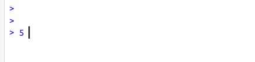

Example of typing a calculation at the command prompt

## Logical operators

R can tell you whether statements are `TRUE` or `FALSE`. These are called **logical statements*.

Table 1: All the basic relational operators

| Operator Symbol | Definition |
| --- | --- |
| `==` | equals to (note the double equals sign) |
| `!=` | not equals to |
| `>` | greater than |
| `>=` | greater than or equal to |
| `<` | less than |
| `<=` | less than or equal to |

```r
# ****************************************************
# Examples of relational calculations -------------------

2 == 3                # Is 2 equal to 3?
```

```
[1] FALSE
```

```r
2 < 3                 # Is 2 less than 3?
```

```
[1] TRUE
```

Here are some more logical statements for you to try

```r
2 != 3                # Is 2 not equal to 3?
'A' == 'B'            # Is 'A' equal to 'B'?
'A' == 'a'            # Is 'A' equal to 'a'?
```

## Have a go

Here are some examples of mathematical functions and operators to try…

```r
# ****************************************************
# Mathematical functions -----------------------------

cos(2/3)              # cosine of 2/3
exp(2)                # exponential function of 2
log10(2)              # logarithm (base 10) of 2
log(2)                # logarithm (base e) of 2
sqrt(2)               # square-root of 2
2^0.5                 # square-root of 2
3^2                   # 3 to the power of 2
round(5/3, digits=3)  # round 5/3 to 3 decimal places
signif(5/3, digits=3) # round 5/3 to 3 significant figures
floor(5/3)            # round 5/3 to the largest integer less than 5/3
abs(-1.4)             # absolute value, ignore the minus sign
```

# Naming Commands (Assigning)

In R you can give anything a name by using the **assignment operator** `<-`

**Note**

Giving a name is called **assignment**

Here is an example where the result of the calculation `2 + 3` is given the name `a` (you can use almost any name you want)

```r
a <- 2 + 3        # Assign the output the name 'a'
a                 # Display the value of 'a'
```

```
[1] 5
```

Once a name is assigned it can be used in place of the result. For example,

```r
a / 10          # Use the name 'a' in a calculation
```

```
[1] 0.5
```

**Note**

Names can also be assigned using `=`. The `=` and `<-` assignment operators are almost identical in how they work.

[figure not shown]

Example of of assigning a name to a number

# Grouping numbers together (arrays)

We will often want to group numbers together (e.g. a group of observations).

**Note**

A collection of several numbers is called an **array**. An array allows one name to be assigned to a group of numbers.

For example, the whole numbers from 1 to 10 could be combined together as an array

```r
c(1,2,3,4,5,6,7,8,9,10)        # An array of numbers
```

```
 [1]  1  2  3  4  5  6  7  8  9 10
```

**Note**

You can find more information on working with arrays at http://DrJonYearsley.github.io/Resources/Manipulate_Data_WebVersion.html

#### Creating an array

An array can be created using the `c()` function that combines several numbers (this is known as the **combine function**)

```r
b <- c(1,2,3,5,7) # An array of the first 5 prime numbers
b                 # Display the value of variable 'b'
```

```
[1] 1 2 3 5 7
```

An array of whole numbers can be quickly created using a colon (:)

```r
c(5:15)         # An array of whole numbers from 5 to 15
```

```
 [1]  5  6  7  8  9 10 11 12 13 14 15
```

# Data types in R

Data can be broadly divided into two types (quantitative and qualitative). Within these two types R makes finer distinctions.

The main data types in R are called:

1. Quantitative data:
- Real numbers: `numeric` (`num`)
- Whole numbers (integers): `integer` (`int`)
2. Qualitative data:
- Text (characters & strings): `character` (`chr`)
- Logicals (booleans): `logical` (`logi`)
- Factors (categorical): `factor`

## Quantitative Data Types

**Numeric (num)**

A typical number (a real number) is given the data type `num` (num standard for numerical). A real number is **quantitative data**.

You can see the data type of a variable using the `str()` function (this function displays the structure of the variable).

```r
x1 <- 2.45          # Numerical (R's data type='num')
str(x1)
```

```
 num 2.45
```

**Integer (int)**

A whole number (an integer) can be given the data type `num`, or it can be explicitly distinguished as a whole number using the data type `int` (int stands for integer). A whole number is **quantitative data**.

You can see the data type of a variable using the `str()` function (this function displays the structure of the variable).

```r
x2 <- 5             # Numerical whole number (R's data type='num')
str(x2)
```

```
 num 5
```

```r
x3 <- as.integer(5) # Numerical whole number (R's data type='int')
str(x3)
```

```
 int 5
```

## Qualitative Data Types

**Note**

Values of a `Factor` are called **levels**

**Factor (factor)**

A factor is a **qualitative variable** that forms a list of names. Qualitative variables are given the data type `Factor`. They are different from a `character` data type because a `Factor` has information about the different values the variable can take

Factors will be important when we start to analyse data because the distinction between quantitative data and qualitative data is important.

**Character (chr)**

Text (either a single letter/number or a series of letters/numbers) is given the data type `chr` (chr standard for character). A character is **qualitative data** (see the section labelled ‘Factor’).

You can see the data type of a variable using the `str()` function (this function displays the structure of the variable).

```r
x4 <- 's'           # Character (R's data type='chr')
str(x4)
```

```
 chr "s"
```

```r
x5 <- 'hello'       # Character string (R's data type='chr')
str(x5)
```

```
 chr "hello"
```

**Logical (logi)**

Logical variables (i.e. variables that can only take the values `TRUE` or `FALSE`) are given the data type `logi` (logi standard for logical).

You can see the data type of a variable using the `str()` function (this function displays the structure of the variable).

```r
x6 <- TRUE          # Logical (TRUE/FALSE) (R's data type='logi')
str(x6)
```

```
 logi TRUE
```

```r
x7 <- NA            # A missing value (R explicitly recognises missing data)
str(x7)
```

```
 logi NA
```

You can see the data type of a variable using the `str()` function (this function displays the structure of the variable).

```r
 # An array of place names as a factor
x8 <- as.factor(c('Dublin','Cork','Galway'))
str(x8)
```

```
 Factor w/ 3 levels "Cork","Dublin",..: 2 1 3
```

# Missing data, `NA`

Missing data are data points points that could not be recorded for some reason. Missing data is an important type of data that R explicitly recognizes. R uses the value `NA` to represent missing data. Missing data should not be set to a value (e.g. 0) because this can be misinterpreted as being the value zero!

Missing data should be included in data sets and explicitly represented. For example, if we had failed to record the number 5 in a data set of whole numbers it would be represented as

```r
# Explicitly record missing data as NA
k <- c(1,2,3,4,NA,6,7)
```

**WarningYou must tell R to ignore NA’s**

R must account for missing data when performing calculations. R will not give an answer if a calculation contains missing data.

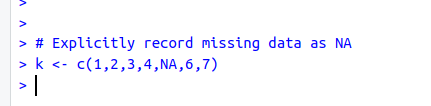

By default R will not remove missing data (see video above)

This means you must tell R to remove missing data before performing a calculation. Many of R’s statistical functions have an argument `na.rm=TRUE` which tells R to remove missing values before performing a calculation.

**If a calculation produces the answer `NA` then try using `na.rm=TRUE`**

```r
mean(k, na.rm=T)   # Calculate mean after removing missing data
```

```
[1] 3.833333
```

# Logical values

A logical value can be either `TRUE` or `FALSE`.

## Single logical expressions

Here are some examples of logical expressions (using some of the operators from above) and their logical output

```r
2.5 > 1          # Is 2.5 greater than 1?
```

```
[1] TRUE
```

```r
-1  <= 3         # Is -1 less than or equal to 3?
```

```
[1] TRUE
```

Some more for you to try…

```r
5 == 2           # Is 5 equal to 2 (NOTE: logical equals is ==)?
5 != 2           # Is 5 not equal to 2?
```

Logical calculations can be performed on an array of numbers. In this example we use the array called `b` from above,

```r
b != 5           # Is each element of b not equal to 5
```

```
[1]  TRUE  TRUE  TRUE FALSE  TRUE
```

## Combining logical expressions

Logical expressions can be combined. There are three basic operations for this (Table 2):

Table 2: The three logical operators that can be used to combine relational operations

| Symbol | Definition |
| --- | --- |
| ! | logical NOT |
| & | logical AND |
| \| | logical OR |

An example of an AND statement

```r
# Combine two logical expressions using & (logical AND)

(b!=5) & (b>2)   # b not equal to 5 AND b greater than 2
```

```
[1] FALSE FALSE  TRUE FALSE  TRUE
```

An example of an OR statement

```r
# Combine two logical expressions using | (logical OR)

(b!=5) | (b>2)   # b not equal to 5 OR b greater than 2
```

```
[1] TRUE TRUE TRUE TRUE TRUE
```

# The continuation prompt, `+`

If we send only part of a command to R it will recognize that the command is incomplete by displaying the **continuation prompt** (the symbol `+`). This prompt means R is waiting for the rest of the command.

**Note**

To remove a continuation prompt and return to the command prompt, press the `Esc` key

## Large and small numbers (exponents)

R uses an **exponent notation** to display very large and very small numbers.

A 70kg human has roughly 30 trillon cells in their body (that is 3 x 10<sup>13</sup> in scientific notation). That’s a large number. R replaces the x 10<sup>+13</sup> with `e+13`

```r
# Number of cells in a 70 kg human
30000000000000
```

```
[1] 3e+13
```

The average weight of a human cell is 70 kg divided by 30 trillion. That’s a very small number. Very small numbers are also represented using the same notation (the `e` in `e-12` stands for exponent).

**Note**

In a scientific report `2.3e-12` should be written in **scientific notation** as 2.3 x 10<sup>-12</sup>.

```r
# Average weight of a human cell (kg)
70 / 3e13
```

```
[1] 2.333333e-12
```

# Summary of topics

- Doing commands (functions and operators)
- Assigning names (assignment)
- Arrays
- R’s data types
- Missing data
- Logical Variables
- Exponential notation for large and small numbers

# Further Reading

All these books can be found in UCD’s library

- Andrew P. Beckerman and Owen L. Petchey, 2012 **Getting Started with R: An introduction for biologists** (Oxford University Press, Oxford) [Chapter 1, 2]
- Mark Gardner, 2012 **Statistics for Ecologists Using R and Excel** (Pelagic, Exeter) [Chapter 3]
- Michael J. Crawley, 2015 **Statistics : an introduction using R** (John Wiley & Sons, Chichester) [Appendix]
- Tenko Raykov and George A Marcoulides, 2013 **Basic statistics: an introduction with R** (Rowman and Littlefield, Plymouth)
- John Verzani, 2005 **Using R for introductory statistics** (Chapman and Hall, London) [Chapter 1]